# Yuma Metals Empirical Distributions and Dimension Reduction - v3

Dean Billheimer

2021-08-28

# Overview

Explore the distributional properties of (hair?) metals concentrations from Yuma, AZ. Also, use Rmd file to illustrate use of R and markdown for computationally reproducible research.

### Changes since 2021-08-21

1. Values missing all metals are true missing – insuffucent sample.
2. Values with missing Hg are also true missing (about 89 of these)
- fit PCA excluding missing Hg
- 2nd fit using imputed Hg from other metals data.
3. drop sample R1108 - missing Cu value - not identified in spectrum. This was included in a batch of samples that failed QA/QC check

### Major changes since 2020-07-03 version

1. Updated data from Jonathan Credo - using 2021-08-23 version - sheet 3
2. Many of the NAs are true missing -
3. Jonathan re-coded BDL values to DL/sqrt(2)
4. Re-run the analysis.
5. Produce a new data set with robust PCA components for Jonathan’s use.

### Major changes since 2020-06-23 version

1. Omit observations where most metals are unmeasured
2. Omit Pb206 and 207
3. What to do about Hg NAs?

### Takeaway

# R Stuff

## Set-up Environment and Read Data

```r
library(readxl)
library(tidyverse)
```

```r
library(ggplot2)

## read data
##filename <- c("Yuma Metals Project - EMR 19Jun20.xlsx")
filename <- c("Yuma Metals Project_EMR_Editted 23Aug2021 mental health & ID removed.xlsx") ## new data set

#Set working directory for my computer - JKH#
setwd("~/Desktop/Research/Yuma/Yuma - R Project/")

tmp <- read_excel(filename, sheet=3)
dim(tmp) ## 330 222 ## same dimensions
```

```
## [1] 330 199
```

```r
 names(tmp)
```

```
##   [1] "ID"                        "Mn55"
##   [3] "Cu65"                      "Cd111"
##   [5] "Hg202"                     "Pb208"
##   [7] "U238"                      "Site"
##   [9] "Date"                      "Gender"
##  [11] "DOB_month"                 "DOB_day"
##  [13] "DOB_year"                  "DOB"
##  [15] "Ethnicity"                 "Race_ai_an"
##  [17] "Race_asian"                "Race_black"
##  [19] "Race_pac_isl"              "Race_white"
##  [21] "Race_other"                "Race_dk"
##  [23] "Race_refuse"               "Race_other_TEXT"
##  [25] "Marital_status"            "Num_in_household"
##  [27] "Num_children"              "Child_under_18"
##  [29] "Education"                 "Education_TEXT"
```

[output cut: 85 more lines]

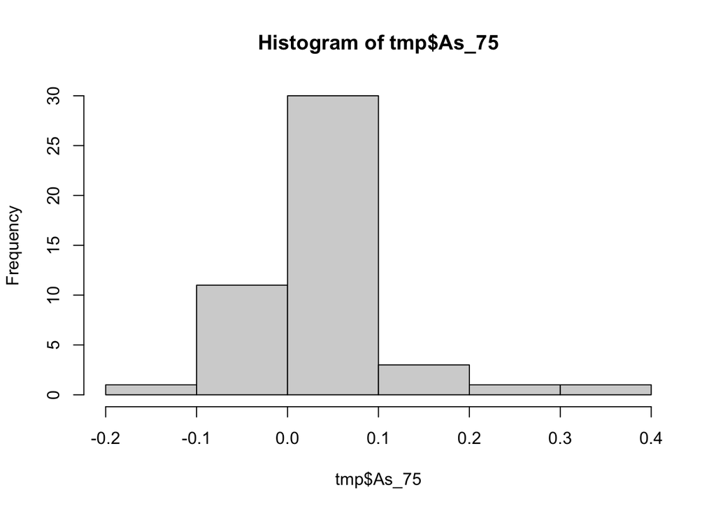

```r
 ##  [1] "ID"                        "Mn55"
 ##  [3] "Cu65"                      "Cd111"
 ##  [5] "Hg202"                     "Pb206"
 ##  [7] "Pb207"                     "PB208"
 ##  [9] "U238"                      "Site"
 ## [11] "Date"                      "Gender"

## head(tmp)

hist(tmp$As_75) #removed from analysis due to negative values - JKH
```

```r
sum(!is.na(tmp$Fe_57)) #removed from analysis due to very low number of samples (n=20) - JKH
```

```
## [1] 20
```

```r
sum(!is.na(tmp$As_75)) #this one only has 47, and 12 of them (~25%) are negative values. - JKH
```

```
## [1] 47
```

```r
## keep only ID, metals and Site, cast to data frame
metals <- data.frame(tmp[,c(1:8)])
names(metals)  ## omitted Pb206 and Pb207
```

```
## [1] "ID"    "Mn55"  "Cu65"  "Cd111" "Hg202" "Pb208" "U238"  "Site"
```

```r
## metals check format
```

## Perform Initial Checks and Summary

The summary below shows there are 123 NAs for nearly all of the metals. Hg202 is the exception with 212 NAs.

Data exploration shows that the NA pattern is consistent across the metals. If one is missing, all are missing.

There are fewer measures at site 1. More missing values at site 1 (51/78) and at site 3 (48/126) compared with site 2 (24/126)

```r
## Initial summary
summary(metals)
```

```
##       ID                 Mn55             Cu65               Cd111
##  Length:330         Min.   :  0.06   Min.   :   0.1626   Min.   :0.0495
##  Class :character   1st Qu.:  0.36   1st Qu.:  10.4350   1st Qu.:0.0495
##  Mode  :character   Median :  0.75   Median :  20.7800   Median :0.0495
##                     Mean   :  3.68   Mean   :  76.2073   Mean   :0.1292
##                     3rd Qu.:  1.72   3rd Qu.:  49.9650   3rd Qu.:0.0495
##                     Max.   :103.32   Max.   :1704.1300   Max.   :3.1000
##                     NA's   :123      NA's   :123         NA's   :123
##      Hg202              Pb208             U238               Site
##  Min.   : 0.00707   Min.   : 0.020   Min.   : 0.03536   Min.   :1.000
##  1st Qu.: 0.13050   1st Qu.: 0.180   1st Qu.: 0.03536   1st Qu.:2.000
##  Median : 0.27300   Median : 0.440   Median : 0.08000   Median :2.000
##  Mean   : 1.59401   Mean   : 1.825   Mean   : 0.36315   Mean   :2.145
##  3rd Qu.: 0.48325   3rd Qu.: 1.160   3rd Qu.: 0.21500   3rd Qu.:3.000
##  Max.   :60.17500   Max.   :76.450   Max.   :21.08000   Max.   :3.000
##  NA's   :212        NA's   :123      NA's   :123
```

```r
## Number of Observations per Site
table(metals$Site) ## 78 126 and 126.  Fewer at site 1
```

```
##
##   1   2   3
##  78 126 126
```

```r
## Number of values > BDL by Site
table(metals$Site, !is.na(metals[,2])) ## Observation indicator by site
```

```
##
##     FALSE TRUE
##   1    51   27
##   2    24  102
##   3    48   78
```

### Metals Concentrations

The figure below shows metals concentrations on log10 scale. NA values are omitted.

The shape of the Pb distributions are nearly identical (omitted 206 and 207). On the whole, these distributions are not as bad as I feared. All are stil right-skewed after transformation, but they do not look pathologic.

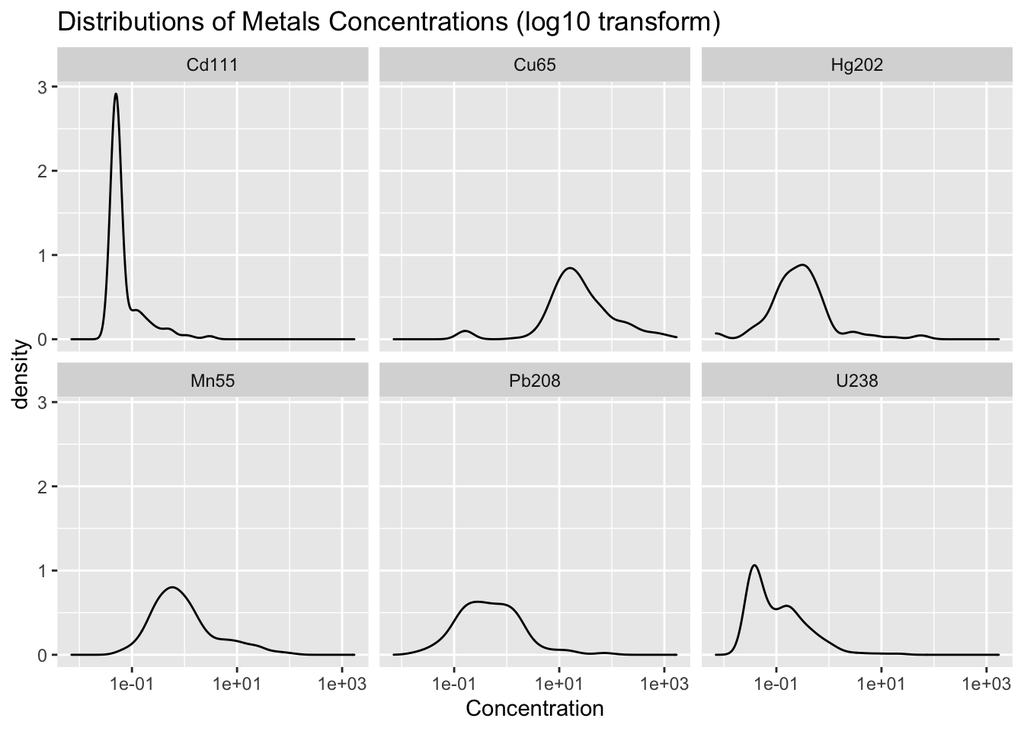

Metals concentrations - log10 scale

```r
## change from wide to long format for plotting

metals %>% pivot_longer(-c(ID, Site), names_to="Metal", values_to="Concentration") %>%
    ggplot(aes(x=Concentration)) + geom_density() +
        scale_x_log10() + facet_wrap(~ Metal) +
            ggtitle("Distributions of Metals Concentrations (log10 transform)")
```

### Remove Missing Values

Values labeled as NA across (nearly all metals) are not measured. For each observation with missing metals, omit the observation. In addition there are 89 observations with missing Hg values. We may impute these missing values based on site and other observed metals

```r
names(metals)
```

```
## [1] "ID"    "Mn55"  "Cu65"  "Cd111" "Hg202" "Pb208" "U238"  "Site"
```

```r
metals.obs <- metals[!is.na(metals[,2]), ]
## for Hg, replace NA and zero with 0.029/sqrt(2)
##sort(metals.obs[,"Hg202"])
## Hg.subs <- 0.029 /sqrt(2)

metals.complete.cases <- metals.obs %>% filter(!is.na(Cu65)) %>%
    filter(!is.na(Hg202)) ## ID R1108 also missing Hg, other metals observed

dim(metals.complete.cases) ## 111 8 wow - small data set
```

```
## [1] 111   8
```

```r
summary(metals.complete.cases)
```

```
##       ID                 Mn55              Cu65               Cd111
##  Length:111         Min.   :  0.070   Min.   :   0.1626   Min.   :0.04950
##  Class :character   1st Qu.:  0.355   1st Qu.:  14.1900   1st Qu.:0.04950
##  Mode  :character   Median :  0.810   Median :  24.7600   Median :0.04950
##                     Mean   :  4.727   Mean   :  94.9425   Mean   :0.13170
##                     3rd Qu.:  2.175   3rd Qu.:  73.0850   3rd Qu.:0.06475
##                     Max.   :103.320   Max.   :1088.6500   Max.   :2.87000
##      Hg202              Pb208             U238              Site
##  Min.   : 0.00707   Min.   : 0.020   Min.   :0.03535   Min.   :1.000
##  1st Qu.: 0.14550   1st Qu.: 0.185   1st Qu.:0.03535   1st Qu.:2.000
##  Median : 0.29100   Median : 0.450   Median :0.08000   Median :2.000
##  Mean   : 1.68130   Mean   : 2.230   Mean   :0.34223   Mean   :2.216
##  3rd Qu.: 0.49500   3rd Qu.: 1.225   3rd Qu.:0.24500   3rd Qu.:3.000
##  Max.   :60.17500   Max.   :76.450   Max.   :9.24000   Max.   :3.000
```

```r
metals.impute.Hg <- metals.obs %>% filter(!is.na(Cu65)) %>%
    filter(is.na(Hg202))

metals.complete.log10 <- cbind(ID=metals.complete.cases[,"ID"],
                               log10(metals.complete.cases[,2:7]),
                               Site=metals.complete.cases[,"Site"])

summary(metals.complete.log10)
```

```
##       ID                 Mn55               Cu65             Cd111
##  Length:111         Min.   :-1.15490   Min.   :-0.7888   Min.   :-1.3054
##  Class :character   1st Qu.:-0.45016   1st Qu.: 1.1520   1st Qu.:-1.3054
##  Mode  :character   Median :-0.09151   Median : 1.3938   Median :-1.3054
##                     Mean   : 0.05038   Mean   : 1.5370   Mean   :-1.1448
##                     3rd Qu.: 0.33745   3rd Qu.: 1.8638   3rd Qu.:-1.2012
##                     Max.   : 2.01418   Max.   : 3.0369   Max.   : 0.4579
##      Hg202             Pb208               U238              Site
##  Min.   :-2.1505   Min.   :-1.69897   Min.   :-1.4515   Min.   :1.000
##  1st Qu.:-0.8373   1st Qu.:-0.73299   1st Qu.:-1.4515   1st Qu.:2.000
##  Median :-0.5361   Median :-0.34679   Median :-1.0969   Median :2.000
##  Mean   :-0.5300   Mean   :-0.31046   Mean   :-0.9353   Mean   :2.216
##  3rd Qu.:-0.3055   3rd Qu.: 0.08784   3rd Qu.:-0.6109   3rd Qu.:3.000
##  Max.   : 1.7794   Max.   : 1.88338   Max.   : 0.9657   Max.   :3.000
```

```r
round(cor(metals.complete.log10[,2:7]), 2)
```

```
##       Mn55 Cu65 Cd111 Hg202 Pb208 U238
## Mn55  1.00 0.48  0.46  0.07  0.55 0.15
## Cu65  0.48 1.00  0.30  0.15  0.59 0.20
## Cd111 0.46 0.30  1.00  0.15  0.60 0.20
## Hg202 0.07 0.15  0.15  1.00  0.21 0.09
## Pb208 0.55 0.59  0.60  0.21  1.00 0.26
## U238  0.15 0.20  0.20  0.09  0.26 1.00
```

```r
metals.impute.log10 <- cbind(ID=metals.impute.Hg[,"ID"],
                               log10(metals.impute.Hg[,2:7]),
                               Site=metals.impute.Hg[,"Site"])
summary(metals.impute.log10)
```

```
##       ID                 Mn55               Cu65             Cd111
##  Length:95          Min.   :-1.22185   Min.   :-0.7888   Min.   :-1.3054
##  Class :character   1st Qu.:-0.43807   1st Qu.: 0.9668   1st Qu.:-1.3054
##  Mode  :character   Median :-0.16749   Median : 1.1884   Median :-1.3054
##                     Mean   :-0.09223   Mean   : 1.1755   Mean   :-1.1551
##                     3rd Qu.: 0.09320   3rd Qu.: 1.4984   3rd Qu.:-1.3054
##                     Max.   : 1.56785   Max.   : 3.2315   Max.   : 0.4914
##
##      Hg202         Pb208               U238              Site
##  Min.   : NA   Min.   :-1.69897   Min.   :-1.4515   Min.   :1.000
##  1st Qu.: NA   1st Qu.:-0.76955   1st Qu.:-1.4515   1st Qu.:2.000
##  Median : NA   Median :-0.38722   Median :-1.1549   Median :2.000
##  Mean   :NaN   Mean   :-0.33314   Mean   :-1.0172   Mean   :2.284
##  3rd Qu.: NA   3rd Qu.:-0.02228   3rd Qu.:-0.7447   3rd Qu.:3.000
##  Max.   : NA   Max.   : 1.30168   Max.   : 1.3239   Max.   :3.000
##  NA's   :95
```

```r
metals.impute.Hg
```

```
##       ID  Mn55         Cu65      Cd111 Hg202 Pb208        U238 Site
## 1  R1005  0.39   59.8300000 0.04949747    NA  0.36  0.03535534    2
## 2  R1001  1.43   33.5000000 0.04949747    NA  0.17  0.07000000    2
## 3  C1005 17.88  179.6800000 0.28000000    NA 20.03  0.14000000    1
## 4  R1011  0.68   44.3900000 0.04949747    NA  0.27  0.06000000    2
## 5  R1009 12.87   13.6600000 0.18000000    NA  6.51  0.25000000    2
## 6  C1013  0.82    9.2600000 0.04949747    NA  0.30  0.03535534    1
## 7  C1014  0.51   32.0500000 0.04949747    NA  0.26  0.03535534    1
## 8  R1018  0.40   18.8100000 0.04949747    NA  0.06  0.03535534    2
## 9  R1019  0.96    9.6300000 0.13000000    NA  2.87  0.03535534    2
## 10 C1017  0.28   13.9100000 0.04949747    NA  0.11  0.03535534    1
## 11 C1022  1.20   22.6400000 0.04949747    NA  0.95  0.15000000    1
## 12 C1026  0.17    6.2200000 0.04949747    NA  1.72  0.22000000    1
## 13 C1018  0.16   22.8200000 0.04949747    NA  0.08  0.23000000    1
## 14 R1021  1.28    0.1626346 0.04949747    NA  0.68  0.03535534    2
```

[output cut: 81 more lines]

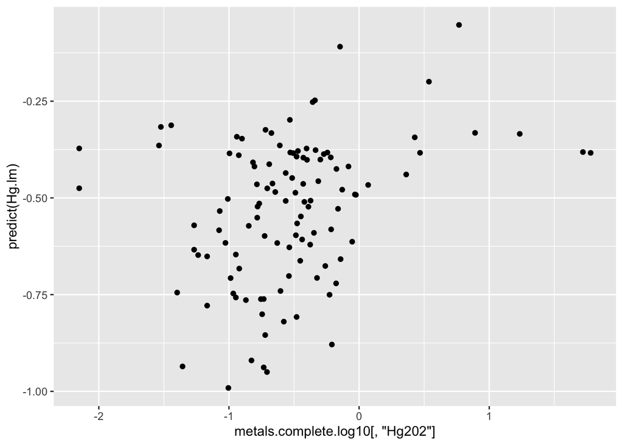

```r
### fit regression line for Hg
Hg.lm <- lm(Hg202 ~ as.factor(Site) + Mn55 + Cu65 + Cd111 + Pb208 + U238,
            data=metals.complete.log10)
qplot(metals.complete.log10[,"Hg202"], predict(Hg.lm))
```

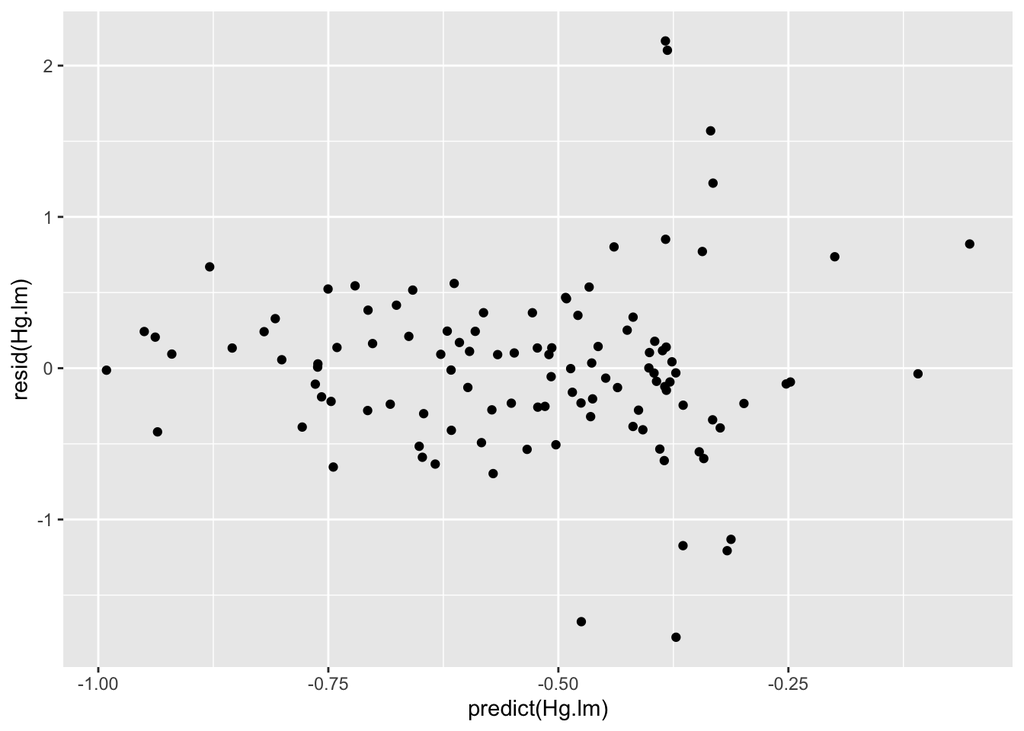

```r
qplot( predict(Hg.lm), resid(Hg.lm))
```

```r
Hg.imputed <-  predict(Hg.lm, newdata=metals.impute.log10)

metals.fillin.log10 <- metals.impute.log10
metals.fillin.log10[,"Hg202"] <- Hg.imputed

summary(metals.fillin.log10)
```

```
##       ID                 Mn55               Cu65             Cd111
##  Length:95          Min.   :-1.22185   Min.   :-0.7888   Min.   :-1.3054
##  Class :character   1st Qu.:-0.43807   1st Qu.: 0.9668   1st Qu.:-1.3054
##  Mode  :character   Median :-0.16749   Median : 1.1884   Median :-1.3054
##                     Mean   :-0.09223   Mean   : 1.1755   Mean   :-1.1551
##                     3rd Qu.: 0.09320   3rd Qu.: 1.4984   3rd Qu.:-1.3054
##                     Max.   : 1.56785   Max.   : 3.2315   Max.   : 0.4914
##      Hg202             Pb208               U238              Site
##  Min.   :-0.9754   Min.   :-1.69897   Min.   :-1.4515   Min.   :1.000
##  1st Qu.:-0.6857   1st Qu.:-0.76955   1st Qu.:-1.4515   1st Qu.:2.000
##  Median :-0.5787   Median :-0.38722   Median :-1.1549   Median :2.000
##  Mean   :-0.5607   Mean   :-0.33314   Mean   :-1.0172   Mean   :2.284
##  3rd Qu.:-0.4261   3rd Qu.:-0.02228   3rd Qu.:-0.7447   3rd Qu.:3.000
##  Max.   :-0.1436   Max.   : 1.30168   Max.   : 1.3239   Max.   :3.000
```

```r
## combine complete cases with Hg imputed cases
metals.allobs.log10 <- rbind(metals.complete.log10, metals.fillin.log10)
## dim(metals.allobs.log10) ## 206 8  ## OK obs with missing Cu65 is omitted.
## dim(metals.obs) ## 207 8

## check summary
summary(metals.allobs.log10)
```

```
##       ID                 Mn55               Cu65             Cd111
##  Length:206         Min.   :-1.22185   Min.   :-0.7888   Min.   :-1.3054
##  Class :character   1st Qu.:-0.44990   1st Qu.: 1.0261   1st Qu.:-1.3054
##  Mode  :character   Median :-0.12494   Median : 1.3212   Median :-1.3054
##                     Mean   :-0.01539   Mean   : 1.3703   Mean   :-1.1495
##                     3rd Qu.: 0.23553   3rd Qu.: 1.7031   3rd Qu.:-1.3054
##                     Max.   : 2.01418   Max.   : 3.2315   Max.   : 0.4914
##      Hg202             Pb208               U238              Site
##  Min.   :-2.1505   Min.   :-1.69897   Min.   :-1.4515   Min.   :1.000
##  1st Qu.:-0.7322   1st Qu.:-0.74473   1st Qu.:-1.4515   1st Qu.:2.000
##  Median :-0.5680   Median :-0.36154   Median :-1.0969   Median :2.000
##  Mean   :-0.5442   Mean   :-0.32092   Mean   :-0.9731   Mean   :2.248
##  3rd Qu.:-0.3821   3rd Qu.: 0.06446   3rd Qu.:-0.6626   3rd Qu.:3.000
##  Max.   : 1.7794   Max.   : 1.88338   Max.   : 1.3239   Max.   :3.000
```

### Adjusted (Hg Imputed) Concentrations

New figure with Hg values imputed using regression on other metals

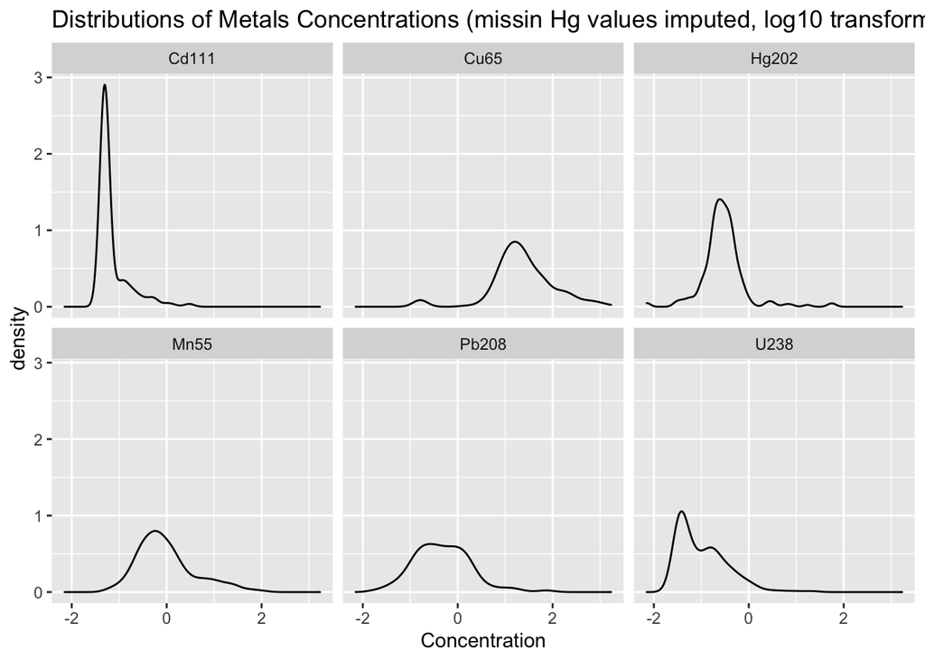

Metals concentrations - log10 scale

```r
## change from wide to long format for plotting

metals.allobs.log10 %>% pivot_longer(-c(ID, Site), names_to="Metal", values_to="Concentration") %>%
    ggplot(aes(x=Concentration)) + geom_density() +
         facet_wrap(~ Metal) +
            ggtitle("Distributions of Metals Concentrations (missin Hg values imputed, log10 transform)")
```

## Robust PCA

Now we move on to Robust PCA. We use the method described by the following papers.

1. Hubert, M., Rousseeuw, P. J., and Vanden Branden, K. (2005), “ROBPCA: A New Approach to Robust Principal Component Analysis,” Technometrics, 47, 64–79.
2. Engelen, S., Hubert, M. and Vanden Branden, K. (2005), “A Comparison of Three Procedures for Robust PCA in High Dimensions”, Austrian Journal of Statistics, 34, 117–126.
3. Hubert, M., Rousseeuw, P. J., and Verdonck, T. (2009), “Robust PCA for Skewed Data and Its Outlier Map,” Computational Statistics & Data Analysis, 53, 2264–2274.

This is implemented in the R package $rospca$

The plot below shows results from the robust PCA. The “Score distance” describes the leverage that an indvidual point has in determining the fitted PCA surface. The “Orthogonal distance” shows the distance to the fitted surface.

The eigenvalues (bottom of the box) show that 61% of the variation is captured in PC1 (41%) and PC2 (20%).

```r
##install.packages("rospca", repos="http://cran.r-project.org")
library(rospca)

##dim(metals.adjusted)
##metals.log10 <- as.matrix(log10(metals.adjusted[, 2:7]))
colnames(metals.allobs.log10)
```

```
## [1] "ID"    "Mn55"  "Cu65"  "Cd111" "Hg202" "Pb208" "U238"  "Site"
```

```r
## round(cor(metals.log10), 2) ## check pairwise correlation
### == original full PCA

metals.pca <- robpca(metals.allobs.log10[,2:7], k=5, alpha=.7, ndir="all", skew=T)

## Eigenvalues show variation in different components
cat("Total Variance in PC1 and PC2\n")
```

```
## Total Variance in PC1 and PC2
```

```r
round(metals.pca[[2]], 3) ## variation in PC's is as expected across components
```

```
##   PC1   PC2   PC3   PC4   PC5
## 0.416 0.195 0.118 0.107 0.050
```

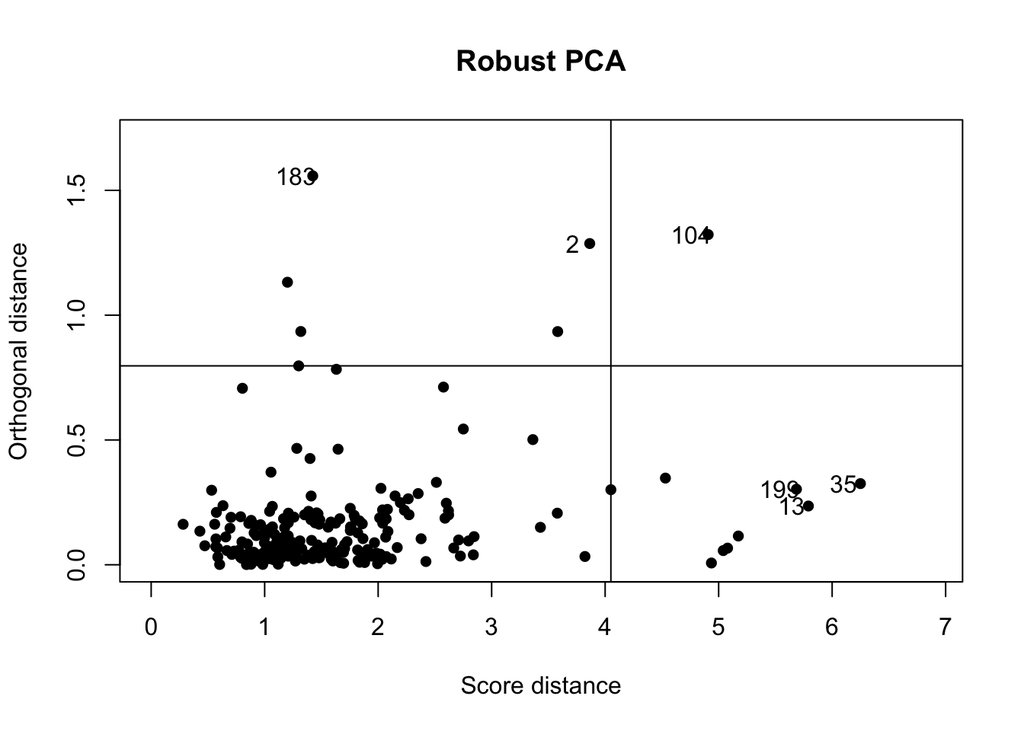

```r
diagPlot(metals.pca)
```

The eigenvalues show that PC1 and PC2 exhibit the majority of the variance, PC 3-5 are smaller. In general, the diagnostic plot suggests that robust PCA is warranted

### PCA Loadings

The loadings are shown below.

```r
round(metals.pca$loadings, 3)
```

```
##         PC1    PC2    PC3    PC4    PC5
## Mn55  0.581  0.064  0.601 -0.533  0.083
## Cu65  0.406  0.269 -0.775 -0.394 -0.035
## Cd111 0.197  0.001 -0.008  0.051  0.007
## Hg202 0.114 -0.036 -0.086  0.181  0.972
## Pb208 0.651 -0.002  0.005  0.708 -0.215
## U238  0.147 -0.960 -0.174 -0.154 -0.041
```

```r
names(metals.allobs.log10[,2:7])
```

```
## [1] "Mn55"  "Cu65"  "Cd111" "Hg202" "Pb208" "U238"
```

```r
##plot(metals.pca$loadings, pch=rownames(metals.pca$loadings))
```

There are a few of points to notice about the loadings

1. All components of PC1 have the same sign. As before, this suggests a “common” effect to all measurements. For example, all metals tend to be “high” or “low” together. May be caused either by global high-low exposure of inviduals, or by mass spectrometry measurement issues.
2. PC1 has highest loading for Pb208, Mn55, and Cu65
3. For PC2, U238 is the biggest driver.

### PCA Scores for Individuals

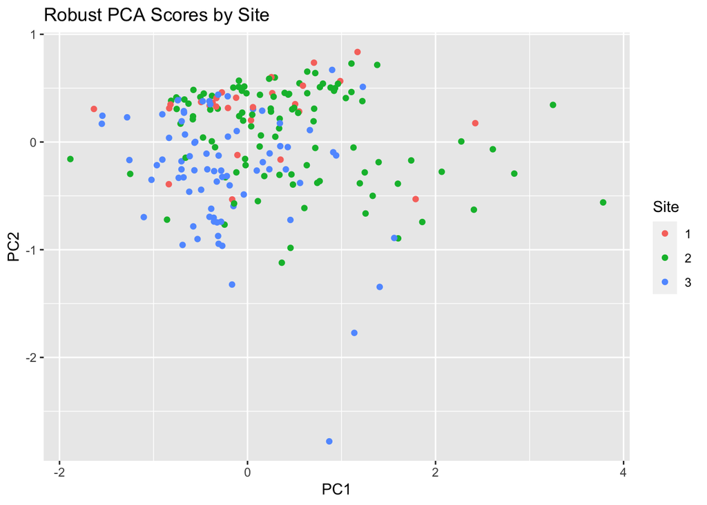

```r
metals.pca.df <- data.frame(Site=factor(metals.allobs.log10$Site), metals.pca$scores) #This is where I updated metals.adjusted$Site to metals.allobs.log10$Site - JKH

qplot(x=PC1, y=PC2, data=metals.pca.df, col=Site,
      main="Robust PCA Scores by Site")
```

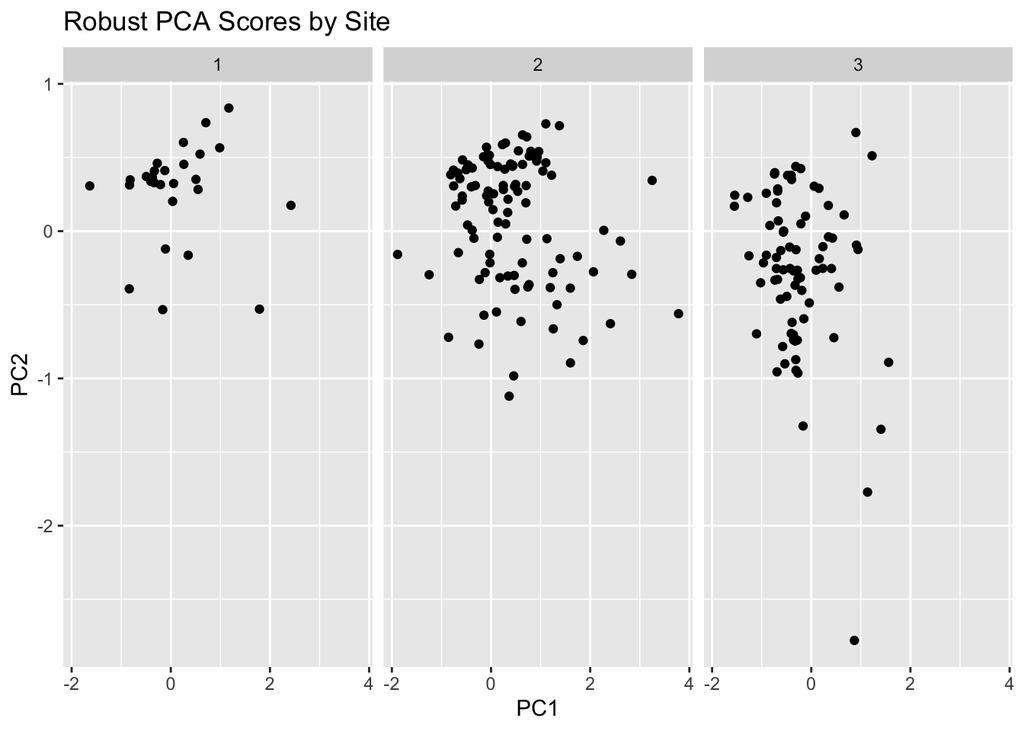

```r
qplot(x=PC1, y=PC2, data=metals.pca.df) + ggtitle("Robust PCA Scores by Site") +
    facet_wrap(~ Site)
```

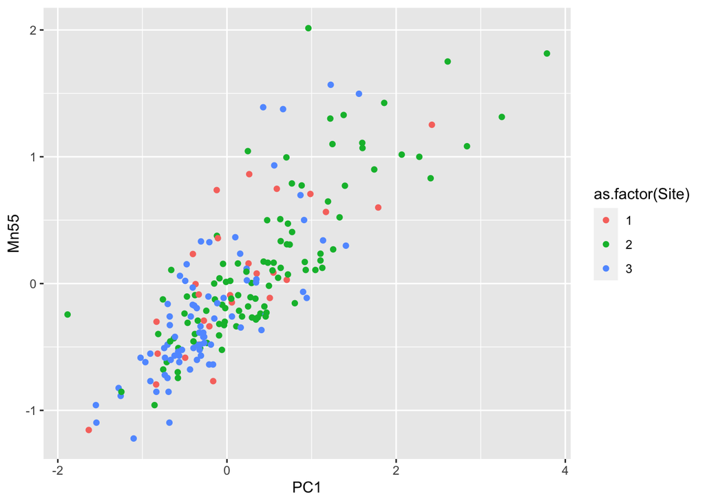

```r
## dim(metals.pca$scores)
## dim(metals.allobs.log10)
## New df on 2021.09.06
metals.robpca <- cbind(metals.allobs.log10, metals.pca$scores)
## dim(metals.robpca)
### about here
qplot(x=PC1, y=Mn55, data=metals.robpca, col=as.factor(Site))
```

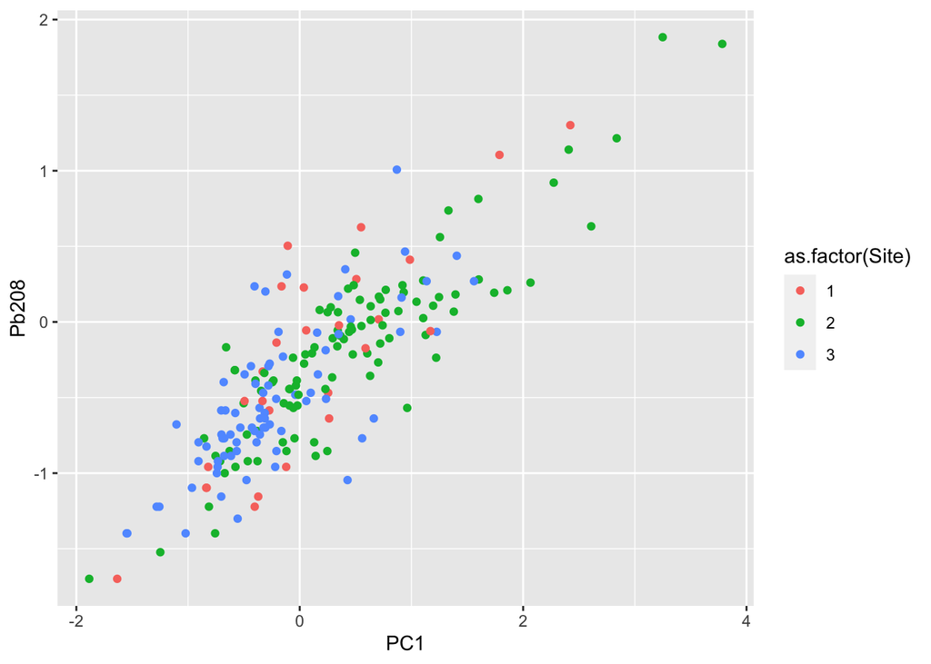

```r
qplot(x=PC1, y=Pb208, data=metals.robpca, col=as.factor(Site))
```

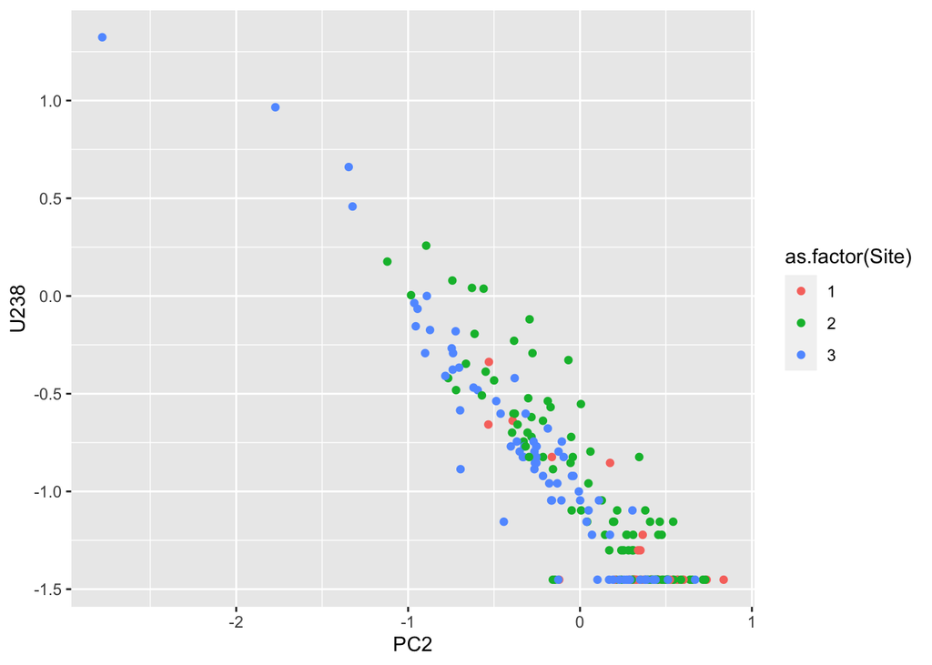

```r
qplot(x=PC2, y=U238, data=metals.robpca, col=as.factor(Site))
```

```r
write.csv(metals.robpca, file="metals_Impute_log10_PCA_scores.csv", quote=F, row.names=F)
```

```r
pca_No_Hg <- robpca(metals.allobs.log10[,c(2:4, 6, 7)], k=5, alpha=.7, ndir="all",
                    skew=T)
pca_No_Hg[[2]] ## .48  .19 .11
```

```
##        PC1        PC2        PC3        PC4        PC5
## 0.47884292 0.18829431 0.10800892 0.08451151 0.01240052
```

```r
round(pca_No_Hg$loadings, 2)
```

```
##        PC1   PC2   PC3   PC4   PC5
## Mn55  0.61  0.17  0.02  0.77  0.10
## Cu65  0.47  0.32  0.68 -0.47  0.03
## Cd111 0.14 -0.05 -0.01  0.03 -0.99
## Pb208 0.56  0.03 -0.70 -0.44  0.07
## U238  0.28 -0.93  0.21 -0.04  0.08
```

```r
## dim(pca_No_Hg$scores) ## 206 5
metals.noHg.robpca <- cbind(metals.allobs.log10, pca_No_Hg$scores)

write.csv(metals.noHg.robpca, file="metals_NoHg_log10_PCA_scores.csv", quote=F, row.names=F)
```

```r
##system("pwd")
rmarkdown::render("yuma-metals-20210821.Rmd", 'html_document')
```